# Datos biológicos en Python

En esta práctica usaremos dos módulos o paquetes de Python:

- BioPython
- Pandas

[BioPython](https://biopython.org/) es un conjunto de herramientas y funcionalidades para trabajar con datos biológicos en Python. En esta práctica usaremos uno de los componentes de BioPython llamado Entrez, que nos permite acceder a información en el NCBI.

[Pandas](https://pandas.pydata.org/) es un paquete que permite trabajar con tablas de datos y manipularlas desde Python y es en la actualidad la herramienta líder en [análisis de datos](https://www.master-data-scientist.com/pandas-herramienta-data-science/).

Para instalar estos paquetes usamos los siguientes comandos:

En Linux:

```
python3 -m pip install "biopython"
```

En Windows:

```
py -m pip install "pandas"
```

Importemos estos módulos:

```python
import pandas as pd # 'as' nos permite ponerle un alias al módulo
from Bio import Entrez # 'from' nos permite carga solamente una parte del módulo
```

En esta práctica usaremos como ejemplo una tabla de datos sobre espaciadores CRISPR. El sistema CRISPR funciona normalmente como un sistema de defensa de las bacterias:

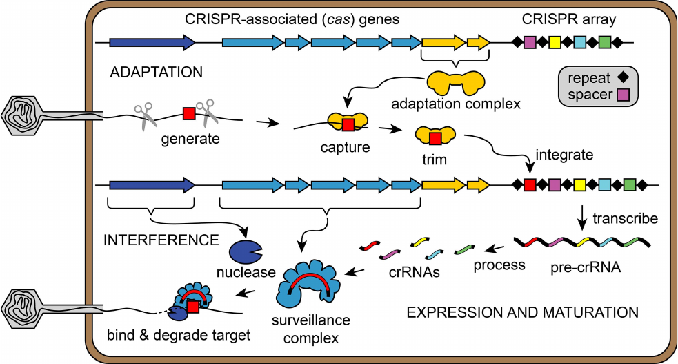

La tabla de datos está disponible en [este enlace](https://github.com/Nesper94/python-bioentrez/blob/main/crispr.csv).

# Pandas

Ahora importaremos la tabla de datos:

```python
df = pd.read_csv('crispr.csv') # df viene de data frame
```

Escribiendo simplemente `df` podemos visualizar parte de la tabla de datos:

```python
df
```

|  | Refseq ID | Organism | Spacer Start | Spacer End | Proto-spacer Start | Proto-spacer End | Source |
| --- | --- | --- | --- | --- | --- | --- | --- |
| 0 | NZ_AVHM01000094 | Clostridioides difficile CD111 gcdCD111. | 3280 | 3317 | 11037 | 11074 | KE Watters ((PMID:30190307)) |
| 1 | NZ_LBKN01000016 | Streptococcus agalactiae strain BG-PW-056 ctg7... | 199298 | 199328 | 23683 | 23713 | KE Watters ((PMID:30190307)) |
| 2 | NZ_FADK01000028 | Clostridioides difficile isolate VL_0183 | 18558 | 18596 | 41024 | 41062 | KE Watters ((PMID:30190307)) |
| 3 | NZ_LFLP01000051 | Campylobacter fetus subsp. testudinum strain 1... | 529 | 565 | 1967 | 2003 | KE Watters ((PMID:30190307)) |
| 4 | NZ_LLTD01000028 | Pseudomonas aeruginosa strain WH-SGI-V-07709 W... | 27553 | 27585 | 469108 | 469140 | KE Watters ((PMID:30190307)) |
| ... | ... | ... | ... | ... | ... | ... | ... |
| 85 | NZ_LBHA01000124 | Kitasatospora aureofaciens strain NRRL 2209 B2... | 24305 | 24337 | 1236 | 1268 | KE Watters ((PMID:30190307)) |
| 86 | NZ_MTAB01000137 | Neisseria sp. 124861 NODE_137_length_297_cov_2... | 99 | 133 | 14044 | 14078 | KE Watters ((PMID:30190307)) |
| 87 | NZ_AKTL01000379 | Yersinia pestis PY-96 PY_96. | 22966 | 22999 | 736 | 769 | KE Watters ((PMID:30190307)) |
| 88 | NC_002950 | Porphyromonas gingivalis W83 | 2104005 | 2104039 | 728638 | 728672 | stern(PMID:20598393) |
| 89 | NZ_CNHT01000053 | Mycobacterium tuberculosis strain Bir 242 | 568 | 608 | 1655 | 1695 | KE Watters ((PMID:30190307)) |

90 rows × 7 columns

Podemos ver solo el principio o el final de la tabla usando `head` o `tail`:

```python
df.head(1)
```

|  | Refseq ID | Organism | Spacer Start | Spacer End | Proto-spacer Start | Proto-spacer End | Source |
| --- | --- | --- | --- | --- | --- | --- | --- |
| 0 | NZ_AVHM01000094 | Clostridioides difficile CD111 gcdCD111. | 3280 | 3317 | 11037 | 11074 | KE Watters ((PMID:30190307)) |

```python
df.tail(2)
```

|  | Refseq ID | Organism | Spacer Start | Spacer End | Proto-spacer Start | Proto-spacer End | Source |
| --- | --- | --- | --- | --- | --- | --- | --- |
| 88 | NC_002950 | Porphyromonas gingivalis W83 | 2104005 | 2104039 | 728638 | 728672 | stern(PMID:20598393) |
| 89 | NZ_CNHT01000053 | Mycobacterium tuberculosis strain Bir 242 | 568 | 608 | 1655 | 1695 | KE Watters ((PMID:30190307)) |

El método `describe` nos permite obtener un resumen de las variables numéricas:

```python
df.describe()
```

|  | Spacer Start | Spacer End | Proto-spacer Start | Proto-spacer End |
| --- | --- | --- | --- | --- |
| count | 9.000000e+01 | 9.000000e+01 | 9.000000e+01 | 9.000000e+01 |
| mean | 3.732457e+05 | 3.732796e+05 | 3.075847e+05 | 3.076186e+05 |
| std | 9.134590e+05 | 9.134591e+05 | 7.174718e+05 | 7.174721e+05 |
| min | 6.500000e+01 | 1.010000e+02 | 3.660000e+02 | 4.000000e+02 |
| 25% | 7.353500e+03 | 7.386500e+03 | 8.426500e+03 | 8.461750e+03 |
| 50% | 4.562650e+04 | 4.566250e+04 | 2.591650e+04 | 2.595050e+04 |
| 75% | 2.210332e+05 | 2.210645e+05 | 1.207918e+05 | 1.208290e+05 |
| max | 4.585277e+06 | 4.585309e+06 | 3.653302e+06 | 3.653340e+06 |

Podemos seleccionar solo una columna usando la notación `df['nombre de la columna']`:

```python
df['Organism']
```

```
0              Clostridioides difficile CD111 gcdCD111.
1     Streptococcus agalactiae strain BG-PW-056 ctg7...
2              Clostridioides difficile isolate VL_0183
3     Campylobacter fetus subsp. testudinum strain 1...
4     Pseudomonas aeruginosa strain WH-SGI-V-07709 W...
                            ...
85    Kitasatospora aureofaciens strain NRRL 2209 B2...
86    Neisseria sp. 124861 NODE_137_length_297_cov_2...
87                         Yersinia pestis PY-96 PY_96.
88                         Porphyromonas gingivalis W83
89            Mycobacterium tuberculosis strain Bir 242
Name: Organism, Length: 90, dtype: object
```

Si queremos varias columnas escribimos `df[['columna 1', 'columna 2']]`:

```python
df[['Organism', 'Spacer Start']]
```

|  | Organism | Spacer Start |
| --- | --- | --- |
| 0 | Clostridioides difficile CD111 gcdCD111. | 3280 |
| 1 | Streptococcus agalactiae strain BG-PW-056 ctg7... | 199298 |
| 2 | Clostridioides difficile isolate VL_0183 | 18558 |
| 3 | Campylobacter fetus subsp. testudinum strain 1... | 529 |
| 4 | Pseudomonas aeruginosa strain WH-SGI-V-07709 W... | 27553 |
| ... | ... | ... |
| 85 | Kitasatospora aureofaciens strain NRRL 2209 B2... | 24305 |
| 86 | Neisseria sp. 124861 NODE_137_length_297_cov_2... | 99 |
| 87 | Yersinia pestis PY-96 PY_96. | 22966 |
| 88 | Porphyromonas gingivalis W83 | 2104005 |
| 89 | Mycobacterium tuberculosis strain Bir 242 | 568 |

90 rows × 2 columns

Podemos también aplicar filtros:

```python
df[(df['Spacer Start'] < 1000) & (df['Spacer End'] > 550)]['Organism']
```

```
3     Campylobacter fetus subsp. testudinum strain 1...
38         Xanthomonas oryzae pv. oryzae strain BXO554
54                 Neisseria meningitidis strain NM1471
70    Pseudomonas aeruginosa strain AZPAE14857 AZPAE...
89            Mycobacterium tuberculosis strain Bir 242
Name: Organism, dtype: object
```

El método `value_counts` nos permite contar cuántas veces aparecen los valores en la tabla de datos:

```python
df['Source']
```

```
0     KE Watters ((PMID:30190307))
1     KE Watters ((PMID:30190307))
2     KE Watters ((PMID:30190307))
3     KE Watters ((PMID:30190307))
4     KE Watters ((PMID:30190307))
                  ...
85    KE Watters ((PMID:30190307))
86    KE Watters ((PMID:30190307))
87    KE Watters ((PMID:30190307))
88            stern(PMID:20598393)
89    KE Watters ((PMID:30190307))
Name: Source, Length: 90, dtype: object
```

```python
df['Source'].value_counts()
```

```
KE Watters ((PMID:30190307))    89
stern(PMID:20598393)             1
Name: Source, dtype: int64
```

Recordemos que es muy útil la función `help` de Python para conocer más sobre un método o una función:

```python
help(df.plot)
```

[output not shown]

[output cut: 876 more lines]

[output not shown]

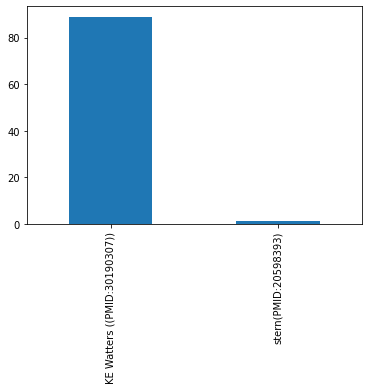

```python
df['Source'].value_counts().plot(kind='bar')
```

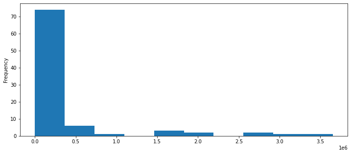

```python
df['Proto-spacer Start'].plot(kind='hist', figsize=(12,5));
```

# BioPython.Entrez

Veamos ahora el funcionamiento de Entrez:

```python
# El NCBI pide un correo
Entrez.email = "juan.arboleda2@udea.edu.co"
```

```python
df.head(1)
```

|  | Refseq ID | Organism | Spacer Start | Spacer End | Proto-spacer Start | Proto-spacer End | Source |
| --- | --- | --- | --- | --- | --- | --- | --- |
| 0 | NZ_AVHM01000094 | Clostridioides difficile CD111 gcdCD111. | 3280 | 3317 | 11037 | 11074 | KE Watters ((PMID:30190307)) |

Podemos descargar nuestras secuencias de interés:

```python
# Obtener información desde las bases de datos de nucleótidos del NCBI
handle = Entrez.efetch(db='nuccore', id='NZ_AVHM01000094', seq_start=11037, seq_stop=11074, rettype='fasta')
```

```python
print(handle.read()) # Mostrar la información obtenida
```

```
>NZ_AVHM01000094.1:11037-11074 Clostridioides difficile CD111 gcdCD111.contig.100, whole genome shotgun sequence
GAAGTTAGAAGATTAGCTTCTCAAGGTGGAGTAAAGGT
```

```python
handle.close() # Liberar el handle
```

También se puede obtener información sobre la secuencia y no la secuencia como tal:

```python
# Obtener información desde las bases de datos de nucleótidos del NCBI
handle = Entrez.efetch(db='nuccore', id='NZ_AVHM01000094', seq_start=11037, seq_stop=11074, rettype='ft')
```

```python
print(handle.read()) # Mostrar la información obtenida
```

```
>Feature ref|NZ_AVHM01000094.1|
<1	>38	gene
			gene	tyrS
			locus_tag	QEC_RS07375
			old_locus_tag	QEC_1491
<1	>38	CDS
			product	tyrosine--tRNA ligase
			EC_number	6.1.1.1
			transl_table	11
			protein_id	ref|WP_009889364.1|
			inference	COORDINATES: similar to AA sequence:RefSeq:WP_003420043.1
```

```python
handle.close() # Liberar el handle
```

Veamos un ejemplo más complejo donde aprovechamos estas herramientas para completar nuestra tabla de datos:

```python
# Create auxiliary lists
products = []
protein_ids = []

# Get feature table of protospacer region
for i, start, end in zip(df['Refseq ID'], df['Proto-spacer Start'], df['Proto-spacer End']):
    try:
        handle = Entrez.efetch(db='nuccore', id=i, seq_start=start, seq_stop=end, rettype='ft')
        feature_table = handle.read().split('\t')
        handle.close()
    except Exception as e:
        print(e, 'Refseq ID:', i, 'Start:', start, 'End:', end)
        products.append('Error: '+str(e))
        protein_ids.append('Error: '+str(e))
        continue

    # Get product name
    try:
        product_idx = feature_table.index('product')
        products.append(feature_table[product_idx + 1].strip())
    except Exception as e:
        print(e, 'Refseq ID:', i, 'Start:', start, 'End:', end)
        products.append('Error: '+str(e))

    # Get protein ID
    try:
        protein_id_idx = feature_table.index('protein_id')
        protein_ids.append(feature_table[protein_id_idx + 1].replace('ref|','').strip('\n|'))
    except Exception as e:
        print(e, 'Refseq ID:', i, 'Start:', start, 'End:', end)
        protein_ids.append('Error: '+str(e))
```

```
'product' is not in list Refseq ID: NZ_LFLP01000051 Start: 1967 End: 2003
'protein_id' is not in list Refseq ID: NZ_LFLP01000051 Start: 1967 End: 2003
HTTP Error 400: Bad Request Refseq ID: NZ_LLTD01000028 Start: 469108 End: 469140
'product' is not in list Refseq ID: NZ_NPOH01000011 Start: 30247 End: 30279
'protein_id' is not in list Refseq ID: NZ_NPOH01000011 Start: 30247 End: 30279
'product' is not in list Refseq ID: PEAH01000002 Start: 3023 End: 3057
'protein_id' is not in list Refseq ID: PEAH01000002 Start: 3023 End: 3057
'product' is not in list Refseq ID: NZ_LEGP01000059 Start: 39778 End: 39810
'protein_id' is not in list Refseq ID: NZ_LEGP01000059 Start: 39778 End: 39810
HTTP Error 400: Bad Request Refseq ID: NZ_NFIH01000027 Start: 159448 End: 159486
'protein_id' is not in list Refseq ID: NC_013124 Start: 1616730 End: 1616764
'product' is not in list Refseq ID: NZ_OAJX01000026 Start: 10932 End: 10962
'protein_id' is not in list Refseq ID: NZ_OAJX01000026 Start: 10932 End: 10962
'protein_id' is not in list Refseq ID: NZ_FAVC01000004 Start: 366 End: 400
'product' is not in list Refseq ID: NZ_QBGW01000002 Start: 105077 End: 105109
'protein_id' is not in list Refseq ID: NZ_QBGW01000002 Start: 105077 End: 105109
'product' is not in list Refseq ID: NZ_LFLP01000032 Start: 1273 End: 1309
'protein_id' is not in list Refseq ID: NZ_LFLP01000032 Start: 1273 End: 1309
HTTP Error 400: Bad Request Refseq ID: NZ_MKMT01000016 Start: 368557 End: 368587
HTTP Error 400: Bad Request Refseq ID: NZ_JVHM01000026 Start: 158273 End: 158305
'product' is not in list Refseq ID: NZ_JXEB01000145 Start: 875 End: 909
'protein_id' is not in list Refseq ID: NZ_JXEB01000145 Start: 875 End: 909
HTTP Error 400: Bad Request Refseq ID: NZ_AXBW01000026 Start: 308333 End: 308367
'product' is not in list Refseq ID: NZ_AHOE02000043 Start: 102629 End: 102661
'protein_id' is not in list Refseq ID: NZ_AHOE02000043 Start: 102629 End: 102661
'product' is not in list Refseq ID: NZ_MDOQ01000007 Start: 4869 End: 4899
'protein_id' is not in list Refseq ID: NZ_MDOQ01000007 Start: 4869 End: 4899
HTTP Error 400: Bad Request Refseq ID: NZ_NYQG01000007 Start: 493392 End: 493427
HTTP Error 400: Bad Request Refseq ID: NZ_CP028929 Start: 1579481 End: 1579513
HTTP Error 400: Bad Request Refseq ID: NZ_AVHA01000043 Start: 7889 End: 7926
HTTP Error 400: Bad Request Refseq ID: NZ_NQKA01000019 Start: 70458 End: 70490
HTTP Error 400: Bad Request Refseq ID: NZ_CAIQ01000135 Start: 425498 End: 425540
'protein_id' is not in list Refseq ID: NZ_JVGD01000106 Start: 2813 End: 2845
'product' is not in list Refseq ID: NZ_CMXA01000033 Start: 10313 End: 10343
'protein_id' is not in list Refseq ID: NZ_CMXA01000033 Start: 10313 End: 10343
'product' is not in list Refseq ID: NZ_JXEY01000005 Start: 2652 End: 2687
'protein_id' is not in list Refseq ID: NZ_JXEY01000005 Start: 2652 End: 2687
'product' is not in list Refseq ID: CP011339 Start: 1905946 End: 1905988
'protein_id' is not in list Refseq ID: CP011339 Start: 1905946 End: 1905988
'product' is not in list Refseq ID: NZ_KQ956191 Start: 628 End: 664
'protein_id' is not in list Refseq ID: NZ_KQ956191 Start: 628 End: 664
HTTP Error 400: Bad Request Refseq ID: CCMO01000163 Start: 45076 End: 45111
HTTP Error 400: Bad Request Refseq ID: AHOJ01000080 Start: 148112 End: 148147
'protein_id' is not in list Refseq ID: NZ_JGYV01000013 Start: 10864 End: 10896
'product' is not in list Refseq ID: CZZV01000014 Start: 32946 End: 32982
'protein_id' is not in list Refseq ID: CZZV01000014 Start: 32946 End: 32982
'product' is not in list Refseq ID: NC_012032 Start: 3653302 End: 3653340
'protein_id' is not in list Refseq ID: NC_012032 Start: 3653302 End: 3653340
'product' is not in list Refseq ID: NZ_OAII01000026 Start: 10929 End: 10959
'protein_id' is not in list Refseq ID: NZ_OAII01000026 Start: 10929 End: 10959
'protein_id' is not in list Refseq ID: NZ_AKWB02000001 Start: 756 End: 788
HTTP Error 400: Bad Request Refseq ID: NZ_FRON01000003 Start: 86204 End: 86236
HTTP Error 400: Bad Request Refseq ID: NZ_MTAB01000137 Start: 14044 End: 14078
```

```python
products
```

```
['tyrosine--tRNA ligase',
 'cysteine desulfurase family protein',
 'ABC transporter permease',
 "Error: 'product' is not in list",
 'Error: HTTP Error 400: Bad Request',
 'thiamine pyrophosphate-requiring protein',
 'N-acetylmuramoyl-L-alanine amidase',
 'Mu transposase C-terminal domain-containing protein',
 "Error: 'product' is not in list",
 "Error: 'product' is not in list",
 "Error: 'product' is not in list",
 'Error: HTTP Error 400: Bad Request',
 'type I-C CRISPR-associated protein Cas7/Csd2',
 '23S ribosomal RNA',
 'transaldolase family protein',
 'hypothetical protein',
 'helix-turn-helix domain-containing protein',
 "Error: 'product' is not in list",
 'histidinol dehydrogenase',
 'chemotaxis protein',
 'penicillin-binding protein 2',
 'HAD family hydrolase',
 'TetR family transcriptional regulator',
 'SIS domain-containing protein',
 'P63C domain-containing protein',
 'RpiB/LacA/LacB family sugar-phosphate isomerase',
 'isoleucine--tRNA ligase',
 'glutamate-5-semialdehyde dehydrogenase',
 "Error: 'product' is not in list",
 'hypothetical protein',
 '1-acyl-sn-glycerol-3-phosphate acyltransferase',
 'BglG family transcription antiterminator',
 'type I-B CRISPR-associated protein Cas8b1/Cst1',
 "Error: 'product' is not in list",
 'Error: HTTP Error 400: Bad Request',
 'bifunctional [glutamate--ammonia ligase]-adenylyl-L-tyrosine phosphorylase/[glutamate--ammonia-ligase] adenylyltransferase',
 'Error: HTTP Error 400: Bad Request',
 'valine--pyruvate transaminase',
 "Error: 'product' is not in list",
 'ATP phosphoribosyltransferase',
```

[output cut: 35 more lines]

```
 'hypothetical protein',
 'type IV conjugative transfer system coupling protein TraD',
 'DNA polymerase III subunit alpha',
 'anaerobic nitric oxide reductase flavorubredoxin',
 'plasmid pRiA4b ORF-3 family protein',
 'valine--pyruvate transaminase',
 'carbamoyl-phosphate synthase (glutamine-hydrolyzing) large subunit',
 'membrane protein',
 'Error: HTTP Error 400: Bad Request',
 'alpha-glucosidase',
 'hypothetical protein',
 'Error: HTTP Error 400: Bad Request',
 'N-methyl-L-tryptophan oxidase',
 'saccharopine dehydrogenase family protein',
 'CRISPR-associated endonuclease Cas1']
```

Con las listas creadas podemos hacer nuevas columnas en la tabla de datos:

```python
# Crear nuevas columnas en la tabla
df['Product'] = products
df['Protein id'] = protein_ids
```

```python
df.head(3)
```

|  | Refseq ID | Organism | Spacer Start | Spacer End | Proto-spacer Start | Proto-spacer End | Source | Product | Protein id |
| --- | --- | --- | --- | --- | --- | --- | --- | --- | --- |
| 0 | NZ_AVHM01000094 | Clostridioides difficile CD111 gcdCD111. | 3280 | 3317 | 11037 | 11074 | KE Watters ((PMID:30190307)) | tyrosine--tRNA ligase | WP_009889364.1 |
| 1 | NZ_LBKN01000016 | Streptococcus agalactiae strain BG-PW-056 ctg7... | 199298 | 199328 | 23683 | 23713 | KE Watters ((PMID:30190307)) | cysteine desulfurase family protein | WP_000639602.1 |
| 2 | NZ_FADK01000028 | Clostridioides difficile isolate VL_0183 | 18558 | 18596 | 41024 | 41062 | KE Watters ((PMID:30190307)) | ABC transporter permease | WP_021365363.1 |

La información se puede obtener en varios formatos:

```python
handle = Entrez.esummary(db='nuccore', id='NZ_LBKN01000016')
```

```python
result = Entrez.read(handle)
```

```python
handle.close()
```

```python
result
```

```
[{'Item': [], 'Id': '827447898', 'Caption': 'NZ_LBKN01000016', 'Title': 'Streptococcus agalactiae strain BG-PW-056 ctg7180000003958, whole genome shotgun sequence', 'Extra': 'gi|827447898|ref|NZ_LBKN01000016.1||gnl|WGS:NZ_LBKN01|ctg7180000003958[827447898]', 'Gi': IntegerElement(827447898, attribute…
```

En la página del NCBI hay [documentación](https://www.ncbi.nlm.nih.gov/books/NBK25499/#_chapter4_EFetch_) sobre el uso de estas herramientas.

También podemos obtener información de bases de datos taxonómicas:

```python
handle = Entrez.efetch(db='taxonomy', id=1311)
```

```python
result = Entrez.read(handle)
```

```python
handle.close()
```

```python
result
```

```
[{'TaxId': '1311', 'ScientificName': 'Streptococcus agalactiae', 'OtherNames': {'Misnomer': [], 'Name': [{'ClassCDE': 'authority', 'DispName': '"Streptoccocus de la mammite" Nocard and Mollereau 1887'}, {'ClassCDE': 'authority', 'DispName': '"Streptococcus agalactiae contagiosae" Kitt 1893'}, {'Clas…
```

El código a continuación es otro ejemplo de cómo se puede usar Entrez para obtener información de las bases de datos del NCBI y usar otras herramientas de Python para procesar esa información y obtener los datos que nos interesan:

```python
# Get Taxonomy ID
# Create auxiliary TaxIds list
TaxIDs = []

for i in df['Refseq ID']:
    try:
        handle = Entrez.esummary(db='nuccore', id=i)
        result = Entrez.read(handle)
        handle.close()
    except Exception as e:
        print(e, 'Refseq ID:', i)
        TaxIDs.append('No NCBI response')
        continue

    try:
        TaxIDs.append(result[0]['TaxId'].real)
    except Exception as e:
        print(e, 'Refseq ID:', i)
        TaxIDs.append('No TaxID')

df['TaxID'] = TaxIDs

# Get species and genus
species_l = []
genus_l = []

for i in df['Organism']:
    split = i.split()
    genus = split[0]
    species = ' '.join(split[0:2])
    species_l.append(species)
    genus_l.append(genus)

df['Species'] = species_l
df['Genus'] = genus_l

# Get additional taxonomic information
superkingdom_l = []
phylum_l = []
class_l = []
order_l = []
family_l = []

for tax_id in df['TaxID']:
    try:
        handle = Entrez.efetch(db='taxonomy', id=tax_id)
        result = Entrez.read(handle)
        handle.close()
    except Exception as e:
        err = 'Error: ' + str(e)
        print(err)
        superkingdom_l.append(err)
        phylum_l.append(err)
        class_l.append(err)
        order_l.append(err)
        family_l.append(err)
        continue

    superkingdom_ = 'Error: No info'
    phylum_ = 'Error: No info'
    class_ = 'Error: No info'
    order_ = 'Error: No info'
    family_ = 'Error: No info'

    for i in result[0]['LineageEx']:
        if i['Rank'] == 'superkingdom':
            superkingdom_ = i['ScientificName']

        elif i['Rank'] == 'phylum':
            phylum_ = i['ScientificName']

        elif i['Rank'] == 'class':
            class_ = i['ScientificName']

        elif i['Rank'] == 'order':
            order_ = i['ScientificName']

        elif i['Rank'] == 'family':
            family_ = i['ScientificName']

    superkingdom_l.append(superkingdom_)
    phylum_l.append(phylum_)
    class_l.append(class_)
    order_l.append(order_)
    family_l.append(family_)

df['Superkingdom'] = superkingdom_l
df['Phylum'] = phylum_l
df['Class'] = class_l
df['Order'] = order_l
df['Family'] = family_l
```

Por último, podemos guardar las modificaciones que hicimos a la tabla en un nuevo archivo CSV:

```python
df.to_csv('tabla-crispr.csv', index=False)
```

O en formato TSV:

```python
df.to_csv('tabla-crispr.tsv', index=False, sep='\t')
```